# Part 1

Isaac Moore

May 17, 2016

### Number 1

In part one we will examine the Central Limit Therom (CLT) by simulating 1000 means of 40 random exponentials using the `{r} rexp()` command.  
**Initalize the data to be used for the analysis.**

```r
set.seed(1987)
lambda <- 0.2
sd <- 1/lambda
sims <- 1000
n <- 40
data <- NULL
```

**Comparing the theoretical mean to the actual mean of the simulated data.**

```r
for(i in 1 : sims){
data <- c(data, mean(rexp(n, lambda)))
}
theoretical_mean <- 1/lambda
theoretical_mean
```

```
## [1] 5
```

```r
actual_mean <- mean(data)
actual_mean
```

```
## [1] 4.987329
```

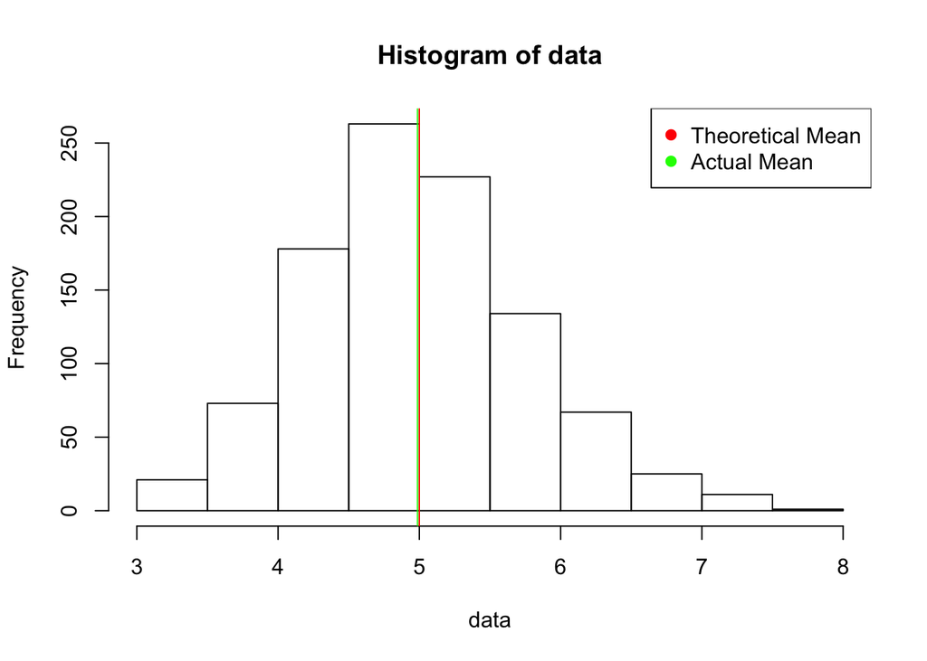

```r
hist(data, breaks = 'Sturges')
abline (v = theoretical_mean, col = 'red')
abline(v = actual_mean, col = 'green')
legend('topright', pch = 19, col = c('red', 'green'), legend = c('Theoretical Mean', 'Actual Mean'))
```

We can see that the actual mean mean is very close to the theoretical mean - the number of simulations we increase, closer the actual mean will get to the theoretical mean.

### Number 2

**Comparing the variance of the actual simulated data to the theoretical variance.**

```r
actual_std_dev <- sd(data)
actual_variance <- actual_std_dev^2
actual_variance
```

```
## [1] 0.6024757
```

```r
theoretical_std_dev <- (1/lambda)/sqrt(n)
theoretical_variance <- theoretical_std_dev^2
theoretical_variance
```

```
## [1] 0.625
```

### Number 3

**Comparing the simulated distribution to the normal distribution.**

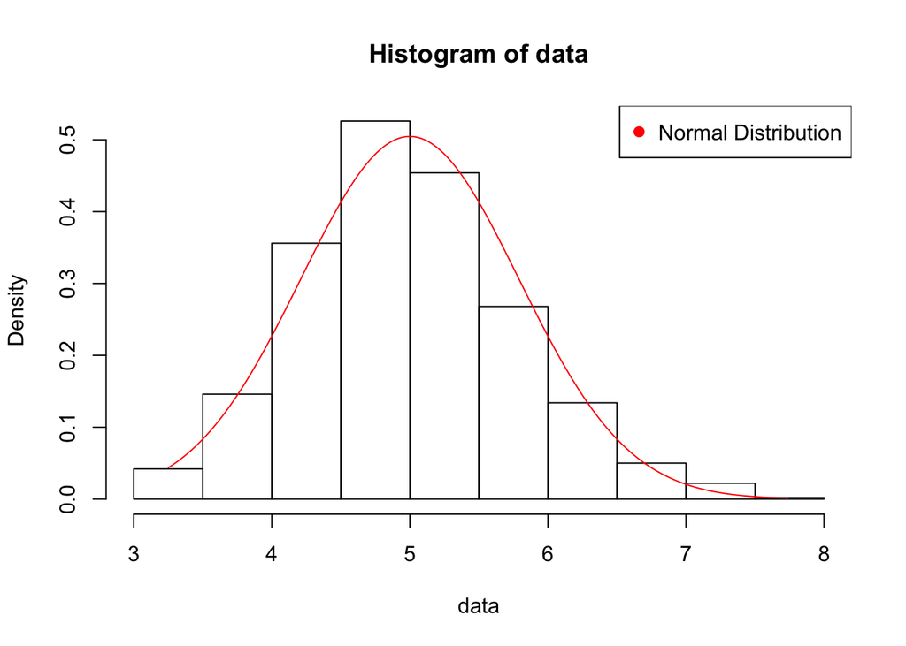

```r
xfit <- seq(min(data), max(data), length=1000)
yfit <- dnorm(xfit, mean=1/lambda, sd=(1/lambda)/sqrt(n))
hist(data, breaks = 'Sturges', probability = T)
lines(xfit, yfit, type ='l', lwd = 1, col = 'red')
legend('topright', pch = 19, col = c('red'), legend = c('Normal Distribution'))
```

We can see that the distribution is very close to being normally distributed. The number of simulations we increase, the closer the distribution will get to being normally distributted.